# Introduction to argoFloats Quality Control

Jaimie Harbin (https://orcid.org/0000-0003-3774-3732), Dan Kelley (https://orcid.org/0000-0001-7808-5911)

2020-07-30

**Abstract**

Argo floats undergo a series of testing to ensure the data provided is a reliable source. Understanding the Quality Control (QC) completed on profiles can be problematic, however. The creators of `argoFloats` therefore developed a way to deal with flags and adjusted data. When dealing with flags, a three step process exists involving `plot(which='QC')`, `showQCTests()`and `applyQC()`. In addition to flag control, `argoFloats` also deals with adjusted data with the `useAdjusted()` function.

# Introduction to Flags

Core, biogeochemical (BGC), and Deep Argo data all undergo testing to ensure the data found at the Data Assembly Centers are as accurate as possible. More specifically, testing is done in three levels: 1: Real time that complete checks on all measurements and assigned a quality flag within a 24-48 hour time frame, 2. Delayed mode, and 3. Regional scientific analyses of all float data with other available data. The procedures for regional analyses are still to be determined.

At first glance, it can be difficult for users to understand the Quality Control (QC) completed on profiles. To address this issue when dealing with Argo data, `argoFloats` created a way to deal with flags and adjusted data. Firstly, the creators of `argoFloats` designed a three step process to deal with flags. Step one is `plot(which='QC')`, which shows the quality and mean of parameters. Step two is `showQCTests()`, which demonstrates which QC tests were performed and failed. Step three is `applyQC()`, which allows the users to get rid of ‘bad’ data if they wish. In addition to flag control, `argoFloats` also deals with adjusted data in `useAdjusted()`, which allows users to use adjusted data if available.

# Flags

`argoFloats` has taken this idea, and has incorporated a 3 step process when considering the quality control of Argo flags. The three step process encourages users to always analyze the data they are considering. The three step process is as follows:

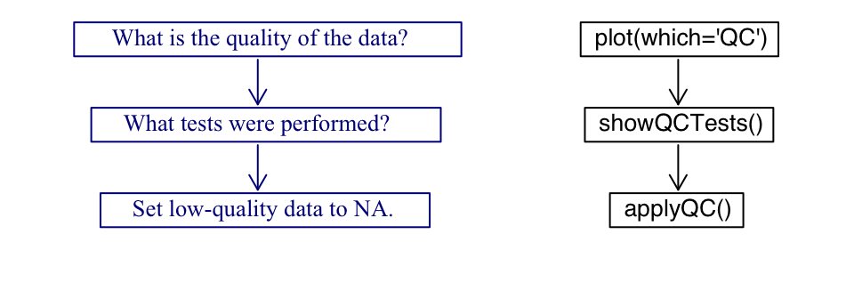

Figure 1: Work flow of the argoFloats package.

This vignette will walk the users through the three step process using the float with ID 1901584 near the Bahamas.

### Step One: QC Plot

An example of how to get the QC plot for temperature, or “TEMP” for the float with ID 1901584 is as follows:

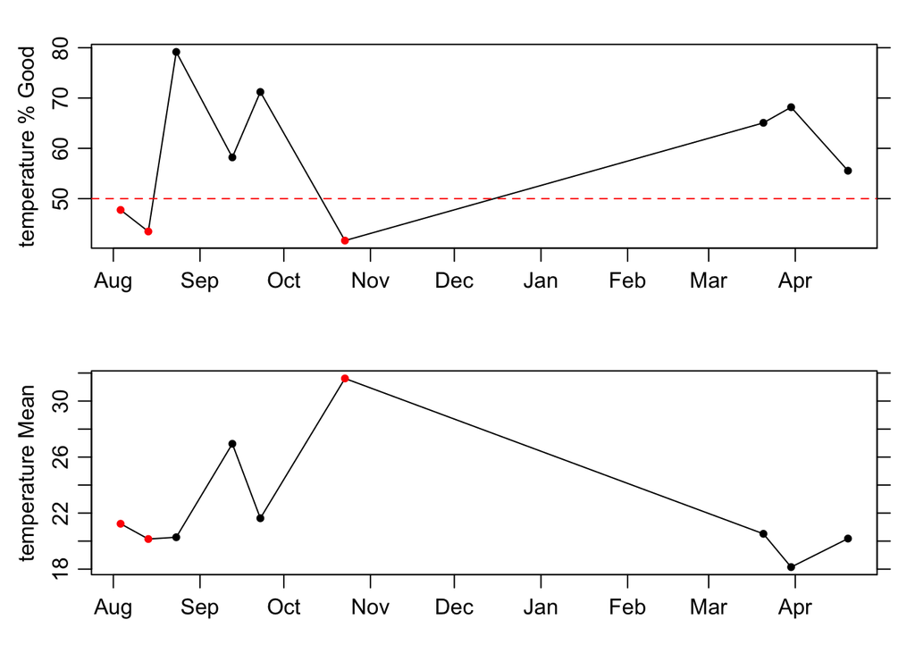

```r
library(argoFloats)
data("index")
subset <- subset(index, ID='1901584')
cycles <- getProfiles(subset)
argos <- readProfiles(cycles)
plot(argos, which='QC', parameter='temperature')
```

*Exercise One:* Use the previous code to determine the QC of temperature for float number 4900845 in synthetic data.Explain your results.

### Step Two: showQCTests()

The `showQCTests()` is a newly added function. It’s purpose is to use integer values from the `hexToNibble()` function to internally convert hex digits. In this context, the hex digits come from `HISTORY_QCTEST` of a single argoFloats object that was created by `readProfiles()`. The `showQCTests()` is then used to indicate which QC tests were performed and/or failed.

Using the same example as shown in `plot(which='QC')`, we can also determine which QC tests were performed on each cycle. This is completed by `showQCTests()` in the following code:

```r
library(argoFloats)
data('index')
subset <- subset(index, 1)
cycles <- getProfiles(subset)
argos <- readProfiles(cycles)
argos1 <- argos[[1]]
showQCTests(argos[[1]])
```

```
## Tests performed: 2 3 4 5 6 13 14 15 16 17 19
##     Failed test 14 (Density Inversion test)
```

*Exercise Two*: Use the first float with ID 4900845 in exercise one,to determine which tests were performed and/or failed during quality control testing. EXPLAIN YOUR RESULTS.

### Step Three: applyQC()

The `applyQC()` function examines quality-control within an argoFloats object that was created by `readProfiles()`. By default, it replaces all suspicious data with NA values, so they will not appear in plots or be considered in calculations. This is an important early step in processing, because suspicious Argo floats commonly report data that are suspicious based on statistical and physical measures.

Using the same example as shown in `plot(which='QC')` and `showQCTests()`, the user also has the ability to use `applyQC()` as shown below:

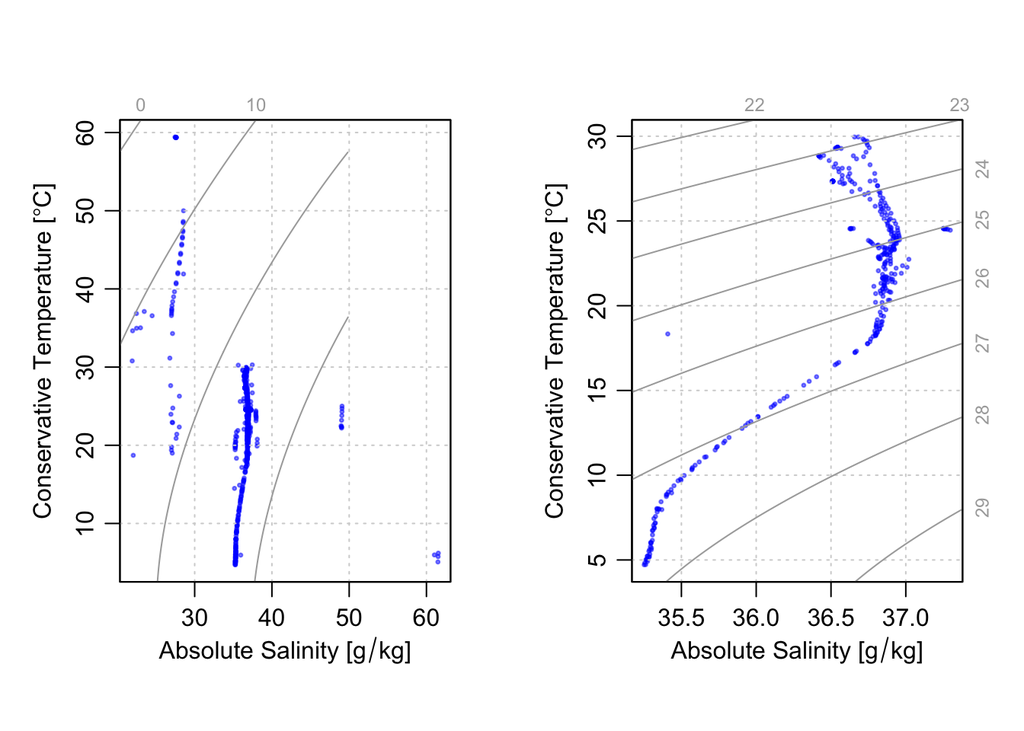

```r
library(argoFloats)
# Contrast TS diagrams for raw and flag-handled data
data(index)
i <- subset(index, ID='1901584')
raw <- readProfiles(getProfiles(i))
clean <- applyQC(raw)
par(mfrow=c(1, 2))
plot(raw, which="TS")
plot(clean, which="TS")
```

*Exercise Three* : Use `applyQC()` on float ID with 4900845. Explain your results.

# Adjusted Data

### useAdjusted()

In addition to flags flagging bad data based on tests, `argoFloats` package has also incorporated the idea of `<param>Adjusted` vs `<param>Unadjusted` which considers “bad” data that has been adjusted [2].

Variables with original names indicating in the string `<param>Adjusted` are assigned nicknames names ending in Adjusted by `readProfiles()`, so that e.g. `doxyAdjusted` gets the nickname `oxygenAdjusted`, while `doxy` gets the nickname `oxygen`. `useAdjusted()` switches these, renaming the adjusted values, so that e.g. `DOXY_ADJUSTED` gets nickname `oxygen` and `DOXY` gets nickname `oxygenUnadjusted`. This is carried out for all data families, and also for the corresponding units and quality-control flags. See `?useAdjusted` to understand when `argoFloats` chooses to use adjusted data.

An example of the significance of adjusted vs unadjusted can be shown below using the ID from the previous flag examples:

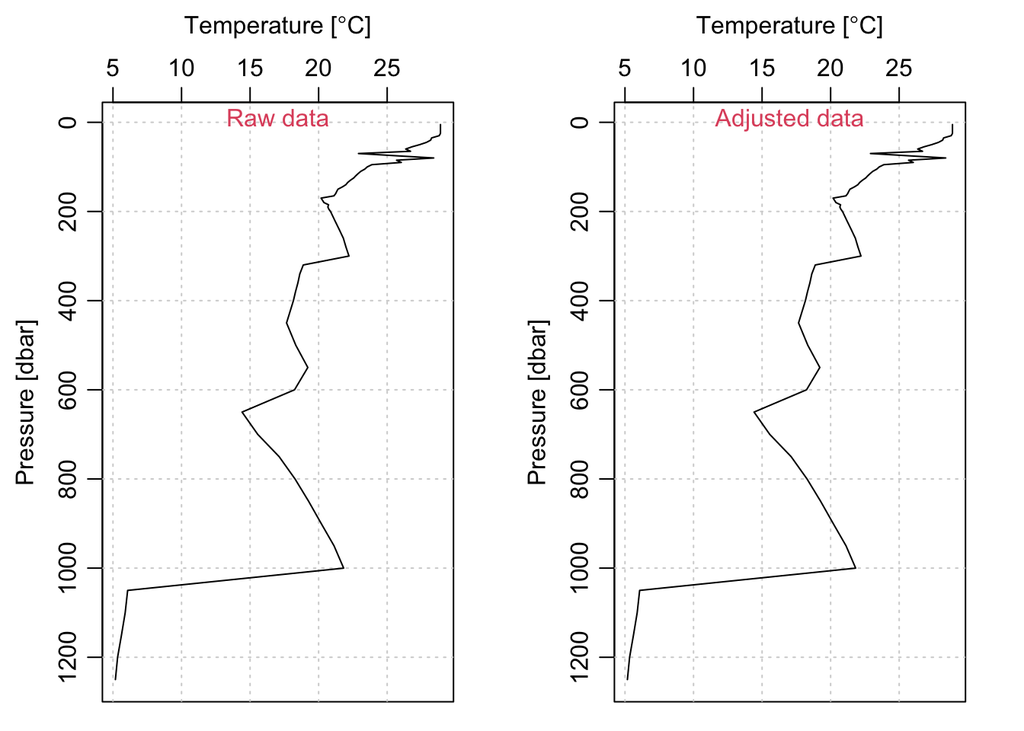

```r
library(argoFloats)
data("index")
subset <- subset(index, ID='1901584')
cycles <- getProfiles(subset)
raw <- readProfiles(cycles)
adj <- useAdjusted(raw)
par(mfrow=c(1, 2))
oce::plotProfile(oce::as.ctd(raw[[1]]), xtype="temperature")
mtext("Raw data", side=3, line=-1, col=2)
oce::plotProfile(oce::as.ctd(adj[[1]]), xtype="temperature")
mtext("Adjusted data", side=3, line=-1, col=2)
```

*Exercise Four* Use `useAdjusted()` on the float with ID5903586, cycle=50 to compare `<param>Adjusted` vs `<param>Unadjusted>`.

# Answers

*Exercise One:* Use the previous code to determine the QC of temperature for float number 4900845 in synthetic data. Explain your results.

```
library(argoFloats)
ais <- getIndex(filename = 'synthetic', age=0)
sub <- subset(ais, ID='4900845')
cycles <- getProfiles(sub)
argos <- readProfiles(cycles)
plot(argos, which='QC', parameter='temperature')
```

*Exercise Two*: Use the first float with ID 4900845 in exercise one,to determine which tests were performed and/or failed during quality control testing. Explain your results.

```
library(argoFloats)
data('indexSynthetic')
sub <- subset(indexSynthetic, ID='4900845')
cycles <- getProfiles(sub)
argos <- readProfiles(cycles)
a1 <- argos[[1]]
showQCTests(a1)
```

*Exercise Three* : Use `applyQC()` on float ID = 4900845. Explain your results.

```
library(argoFloats)
# Contrast TS diagrams for raw and flag-handled data
data(indexSynthetic)
i <- subset(index, ID='4900845')
raw <- readProfiles(getProfiles(i))
clean <- applyQC(raw)
par(mfrow=c(1, 2))
plot(raw, which="TS")
plot(clean, which="TS")
```

*Exercise Four* Use `useAdjusted()` on the float with ID 5903586, cycle=50 to compare `<PARAM>_ADJUSTED` vs `<param>Unadjusted`.

```
library(argoFloats)
bai <- getIndex('synthetic')
s <- subset(bai, ID='5903586')
ss <- subset(s, 50)
cycles <- getProfiles(ss)
raw <- readProfiles(cycles)
adj <- useAdjusted(raw)
par(mfrow=c(1, 2))
oce::plotProfile(oce::as.ctd(raw[[1]]), xtype="oxygen")
mtext("Raw data", side=3, line=-1, col=2)
oce::plotProfile(oce::as.ctd(adj[[1]]), xtype="oxygen")
mtext("Adjusted data", side=3, line=-1, col=2)
```

# References

1. Wong, A., Keeley, R. and Carval, T., 2009. Argo quality control manual. Version, 2(5), p.32.
2. Carval, Thierry, Bob Keeley, Yasushi Takatsuki, Takashi Yoshida, Stephen Loch Loch, Claudia Schmid, and Roger Goldsmith. Argo User’s Manual V3.3. Ifremer, 2019. https://doi.org/10.13155/29825.